# American Brewery Study for Budweiser

Josh Eysenbach and Julia Layne

2/17/2020

# Introduction

## A New Beer label; IPA vs APA - Does it matter?

Based on your interest in creating a new beer label. We’ve evaluated over 2400 labels in this dataset, a third of them are classified as IPA or the similar APA. If Budweiser desires to cut into the craft brew market, this is an excellent place to start.

We will show that there is a statewide differences in median IBUs while ABVs are relatively close. We determined there relationship between ABV and IBUs and these can be used to categorize beer style. Finally, there are distinct differences in ABV and IBU between Standard American IPA’s, Double IPA’s, and APA’s.

Based on this information, it would be prudent for Budweiser’s brewers to stick to the range for American IPA’s shown in this dataset of an IBU between 60-75 to be within the range of 50% of American IPA’s on market. IPAs tend to be on the higher alcohol content, but there are ABVs within the American IPA range and the overall middle 50% of ABVs of 6.2% to 6.7%. Staying within this range will keep it distinct from the American Pale Ales while not straying far from the drinkability people look for in Budweiser.

In our review we found many beers were missing information on their IBU. This scale is not as widespread in America as it is in other countries. When Adolphus Busch started Budweiser, he was looking to make Americans love beer. Now Budweiser could bring this distinct flavor to a broader audience by inviting them to fall in love with the American IPA.

### “It is my aim to win the American people over … to make them all lovers of beer.” - Adolphus Busch (1905)

[Referenced From Budweiser’s Website](https://www.budweiser.com/en/our-legacy.html)

# Questions

Here are the specific questions you requested, above each you will find a brief explanation of the code contained to generate the data.

## Initial Setup

### Libraries

These are the r libraries we used to evaluate the brewery and beer datasets

```r
library(tidyverse)
library(ggthemes)
library(caret)
library(mvtnorm)
library(class)
library(e1071)
library(usmap)
```

## Import Files

Included with this evaluation are the provided CSVs of Beer and Brewery data. Please leave them in the same folder when running this file.

See Appendix for Raw Datasets

```r
#import data
beers <- read.csv("Beers.csv",header = TRUE)
breweries <- read.csv("Breweries.csv",header = TRUE)
```

## 1. How many breweries are present in each state?

### Brewery Counts by State

Here we are taking the brewery dataset and sorting by the state abbreviation. We have sorted it for easier readability and comparison starting with state with most breweries: Colorado. Every state is represented by at least one brewery in this list as well as the Distric of Columbia.

```r
print(breweries %>% count(State,sort=TRUE), n = 51)
```

```
## # A tibble: 51 x 2
##    State     n
##    <fct> <int>
##  1 " CO"    47
##  2 " CA"    39
##  3 " MI"    32
##  4 " OR"    29
##  5 " TX"    28
##  6 " PA"    25
##  7 " MA"    23
##  8 " WA"    23
##  9 " IN"    22
## 10 " WI"    20
## 11 " NC"    19
## 12 " IL"    18
```

[output cut: 39 more lines]

### Brewery Count on United States Map

Additionally, here are those state counts displayed in map format to see concentrations of breweries to coastal regions: Pacific, Atlantic, and the great lakes. Colorado and Texas really stand out in the central region.

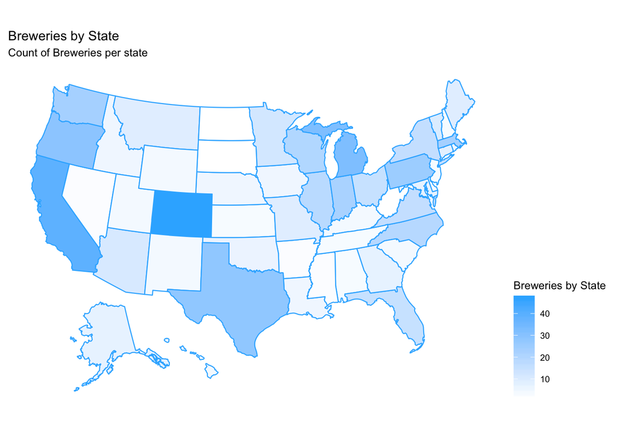

```r
brew_count_by_state <- breweries %>% group_by(State) %>% tally()
brew_count_by_state$state <- trimws(as.character(brew_count_by_state$State))
brew_count_by_state$fips <- fips(brew_count_by_state$state)
attach(brew_count_by_state)
brew_count_fips <- brew_count_by_state[order(fips),]
detach(brew_count_by_state)

plot_usmap(data = brew_count_fips,  values = "n", color = rgb(.2, .7, 1)) +
    labs(title = "Breweries by State", subtitle = "Count of Breweries per state") +
  scale_fill_continuous(low = "white", high = rgb(.2, .7, 1), name = "Breweries by State", label = scales::comma) + theme(legend.position = "right")
```

## 2. Merge Beer and Brewery Data

To bring these two datasets together we have joined them on the brewery’s id. The Name columns of each were transformed to Brewery_Name and Beer_Name for better readability. Below are the first and last 6 beers from the joined datasets.

```r
#Merge the datasets
Beer2 <- merge(beers, breweries, by.x = "Brewery_id", by.y = "Brew_ID")
#Rename the Beer and Brewery Columns
Beer2 <- Beer2 %>%
  rename(
    Brewery_Name = Name.y,
    Beer_Name = Name.x
    )
#Display the first and last 6 rows
head(Beer2, 6)
```

```
##   Brewery_id     Beer_Name Beer_ID   ABV IBU
## 1          1  Get Together    2692 0.045  50
## 2          1 Maggie's Leap    2691 0.049  26
## 3          1    Wall's End    2690 0.048  19
## 4          1       Pumpion    2689 0.060  38
## 5          1    Stronghold    2688 0.060  25
## 6          1   Parapet ESB    2687 0.056  47
##                                 Style Ounces       Brewery_Name        City
## 1                        American IPA     16 NorthGate Brewing  Minneapolis
## 2                  Milk / Sweet Stout     16 NorthGate Brewing  Minneapolis
## 3                   English Brown Ale     16 NorthGate Brewing  Minneapolis
## 4                         Pumpkin Ale     16 NorthGate Brewing  Minneapolis
## 5                     American Porter     16 NorthGate Brewing  Minneapolis
## 6 Extra Special / Strong Bitter (ESB)     16 NorthGate Brewing  Minneapolis
##   State
## 1    MN
## 2    MN
## 3    MN
## 4    MN
## 5    MN
## 6    MN
```

```r
tail(Beer2, 6)
```

```
##      Brewery_id                 Beer_Name Beer_ID   ABV IBU
## 2405        556             Pilsner Ukiah      98 0.055  NA
## 2406        557  Heinnieweisse Weissebier      52 0.049  NA
## 2407        557           Snapperhead IPA      51 0.068  NA
## 2408        557         Moo Thunder Stout      50 0.049  NA
## 2409        557         Porkslap Pale Ale      49 0.043  NA
## 2410        558 Urban Wilderness Pale Ale      30 0.049  NA
##                        Style Ounces                  Brewery_Name          City
## 2405         German Pilsener     12         Ukiah Brewing Company         Ukiah
## 2406              Hefeweizen     12       Butternuts Beer and Ale Garrattsville
## 2407            American IPA     12       Butternuts Beer and Ale Garrattsville
## 2408      Milk / Sweet Stout     12       Butternuts Beer and Ale Garrattsville
## 2409 American Pale Ale (APA)     12       Butternuts Beer and Ale Garrattsville
## 2410        English Pale Ale     12 Sleeping Lady Brewing Company     Anchorage
##      State
## 2405    CA
## 2406    NY
## 2407    NY
## 2408    NY
## 2409    NY
## 2410    AK
```

## 3. Address Missing Values

There are a few ways we could go about dealing with these; the best way to glean reliable information from any statistics related to the data would be to ignore entries with missing values for the variable(s) being examined, as using any input (like say, a mean) in place of an unknown value is very likely to misrepresent the true nature of the data.

In this case, IBU is a good example of the potential perils of trying to impute missing values because it varies greatly between beers regardless of style. The IBU measurement is going to be impacted heavily by the flavor/taste a brewer is going for, and breweries have little practical interest in producing beers that aren’t distinguishably different than those they already have, especially if they will produce multiple iterations of a certain style. The best course of action is probably to exclude beers missing the IBU value when examining IBU despite the misfortune that this excludes over 1000 beers (40% of the beers).

For similar reasons, beers missing ABV should also be excluded from analyses involving ABV. There is less reason for concern with these exclusions due to the relatively small number of beers missing this information.

### Columns with missing Values

```r
#Find out which columns have missing values
names(which(colSums(is.na(Beer2))>0))
```

```
## [1] "ABV" "IBU"
```

### Counts of Missing Values

```r
#Count the missing values in each column
paste('ABV Missing - ',sum(is.na(Beer2$ABV)))
```

```
## [1] "ABV Missing -  62"
```

```r
paste('IBU Missing - ', sum(is.na(Beer2$IBU)))
```

```
## [1] "IBU Missing -  1005"
```

```r
paste('Style Missing - ', sum(is.na(Beer2$Style)))
```

```
## [1] "Style Missing -  0"
```

## 4. Compute the median alcohol content and international bitterness unit for each state. Plot a bar chart to compare.

We took the median ABV and IBU per state, removing respective missing values. The median ABVs per state are relatively close to one another between 0.04 and .0625. Utah stands out with a very low median of 0.04 ABV. This is likely due to a law capping the alcohol content at 4%. Considering that there are not laws around the IBU, the median IBUs are much more diverse ranging from around 20 - 60 IBUs

See Appendix for full ordered lists of

Median ABV

Median IBU

```r
Meds <- Beer2 %>%
  group_by(State) %>%
  summarize(
    Median_ABV = median(ABV, na.rm = TRUE),
    Median_IBU = median(IBU, na.rm = TRUE)
  )
```

### Bar Charts of ABV and IBU

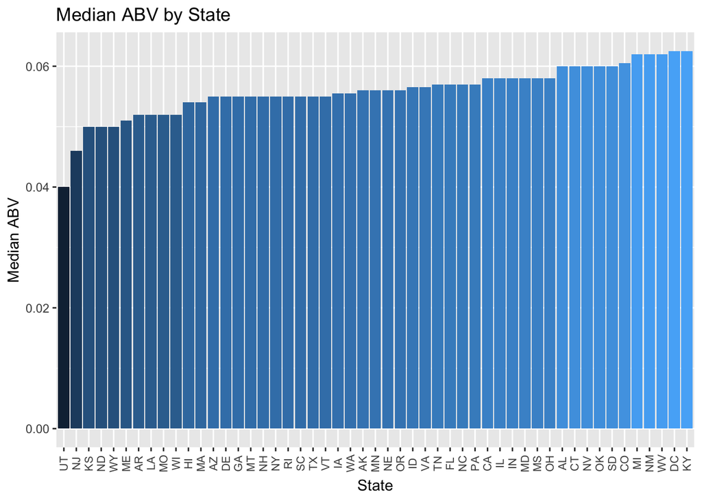

```r
Meds %>% ggplot(aes(x=reorder(State,Median_ABV), y=Median_ABV,fill = Meds$Median_ABV)) + scale_colour_gradient()+ geom_col(show.legend = FALSE) + ggtitle("Median ABV by State") + xlab("State") + ylab("Median ABV") + theme(axis.text.x = element_text(angle=90, size=8, vjust = .5))
```

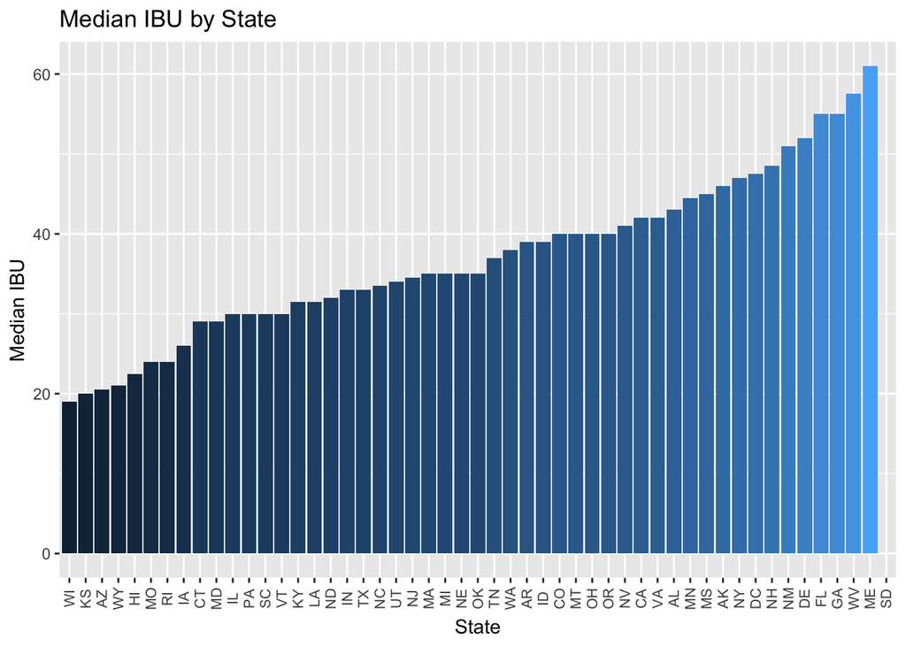

```r
Meds %>% ggplot(aes(x=reorder(State,Median_IBU), y=Median_IBU,fill = Meds$Median_IBU)) + scale_colour_gradient()+ geom_col(show.legend = FALSE) + ggtitle("Median IBU by State") + xlab("State") + ylab("Median IBU") + theme(axis.text.x = element_text(angle=90, size=8, vjust = .5))
```

With these Medians, we have charted the states to better view the distributions geographically. South Dakota is missing from the IBU map. Given that 40% of the beers didn’t have IBU values and many states only had one brewery, like South Dakota, it isn’t surprising there is a state missing from this map.

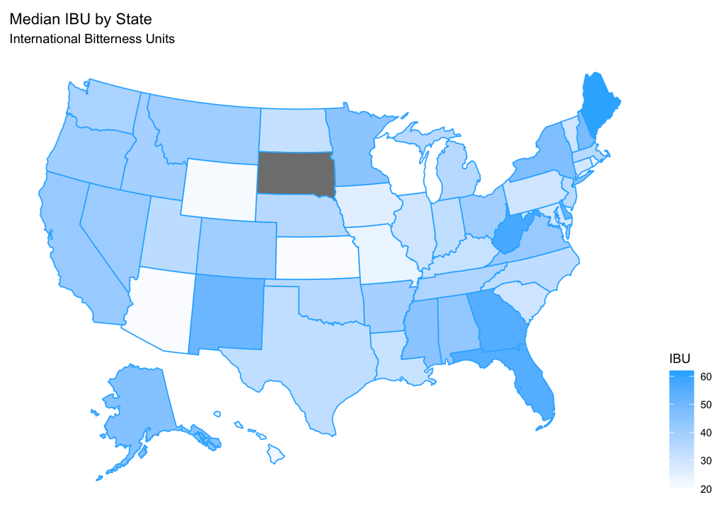

```r
Meds$fips <- fips(trimws(as.character(Meds$State)))
plot_usmap(data = Meds,  values = "Median_IBU", color = rgb(.2, .7, 1)) +
    labs(title = "Median IBU by State", subtitle = "International Bitterness Units") +
  scale_fill_continuous(low = "white", high = rgb(.2, .7, 1), name = "IBU", label = scales::comma) + theme(legend.position = "right")
```

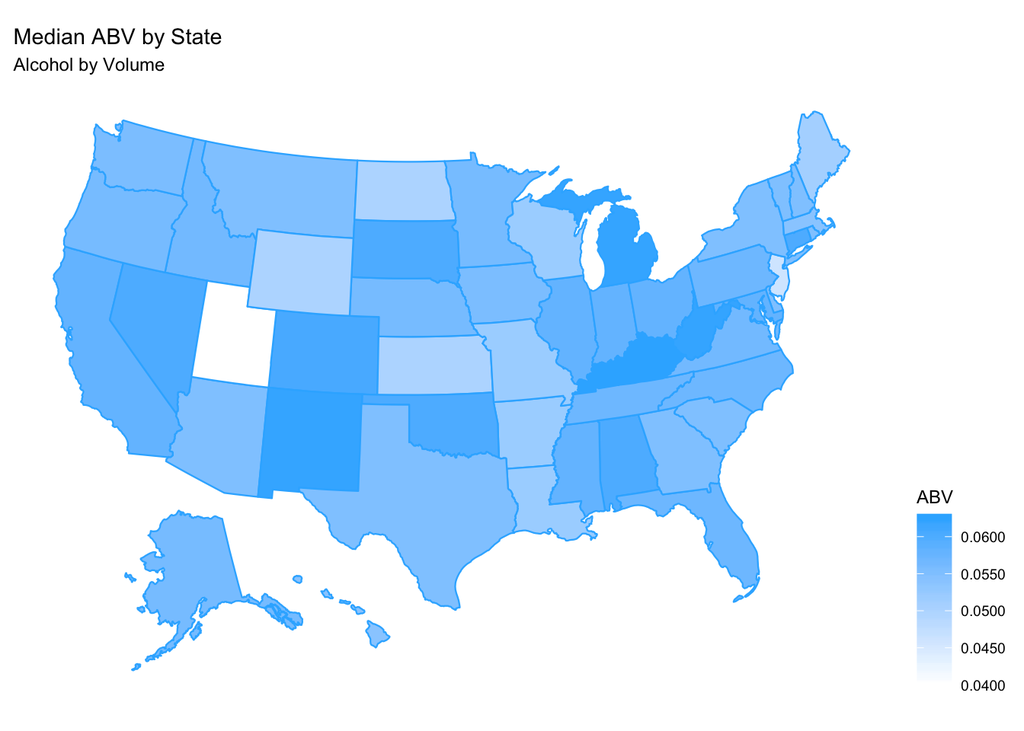

```r
plot_usmap(data = Meds,  values = "Median_ABV", color = rgb(.2, .7, 1)) +
    labs(title = "Median ABV by State", subtitle = "Alcohol by Volume") +
  scale_fill_continuous(low = "white", high = rgb(.2, .7, 1), name = "ABV", label = scales::comma) + theme(legend.position = "right")
```

## 5. Which state has the maximum alcoholic (ABV) beer? Which state has the most bitter (IBU) beer?

### Highest ABV:

```r
#State in which the beer with the single highest ABV resides
maxABV = max(Beer2$ABV, na.rm = TRUE)
topABV = Beer2$`State`[which(Beer2$ABV==maxABV)]
paste('State with the highest ABV: ', topABV, ' - ', maxABV, 'ABV')
```

```
## [1] "State with the highest ABV:   CO  -  0.128 ABV"
```

```r
#State in which the beer with the single highest IBU resides
maxIBU = max(Beer2$IBU, na.rm = TRUE)
topIBU = Beer2$`State`[which(Beer2$IBU==maxIBU)]
paste('State with the highest ABV: ', topIBU, ' - ', maxIBU, 'IBU')
```

```
## [1] "State with the highest ABV:   OR  -  138 IBU"
```

```r
#States with the highest median ABV
maxMedABV = max(Meds$Median_ABV, na.rm = TRUE)
topMedABV = Meds$`State`[which(Meds$Median_ABV==maxMedABV)]
paste('States with the highest median ABV (tie): ')
```

```
## [1] "States with the highest median ABV (tie): "
```

```r
paste(topMedABV, ' - ', maxMedABV, 'ABV')
```

```
## [1] " DC  -  0.0625 ABV" " KY  -  0.0625 ABV"
```

```r
#States with the highest median IBU
maxMedIBU = max(Meds$Median_IBU, na.rm = TRUE)
topMedIBU = Meds$`State`[which(Meds$Median_IBU== maxMedIBU)]
paste('States with the highest median IBU: ', topMedIBU, ' - ', maxMedIBU, 'IBU')
```

```
## [1] "States with the highest median IBU:   ME  -  61 IBU"
```

## 6. Summary Statistics of ABV

```r
summary(Beer2$ABV)
```

```
##    Min. 1st Qu.  Median    Mean 3rd Qu.    Max.    NA's
## 0.00100 0.05000 0.05600 0.05977 0.06700 0.12800      62
```

```r
sd(Beer2$ABV, na.rm = TRUE) #Standard deviation
```

```
## [1] 0.01354173
```

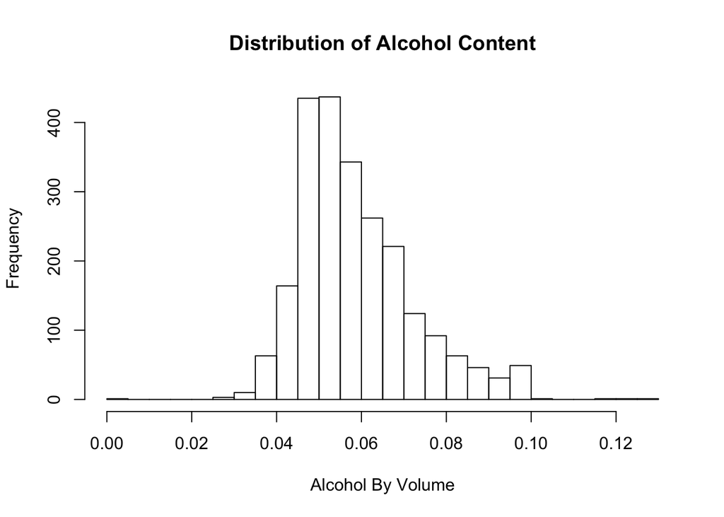

```r
hist(Beer2$ABV, breaks = 20, main = "Distribution of Alcohol Content", xlab = "Alcohol By Volume")
```

## 7. Assess any relationship between ABV and IBU. Note: We are removing entries with missing values.

Based on a scatter plot of ABV vs IBU, there does appear to be evidence of a moderate positive correlation. The ABV looks like it trends upward as IBU increases. The calculated correlation coefficient of .67 supports this.

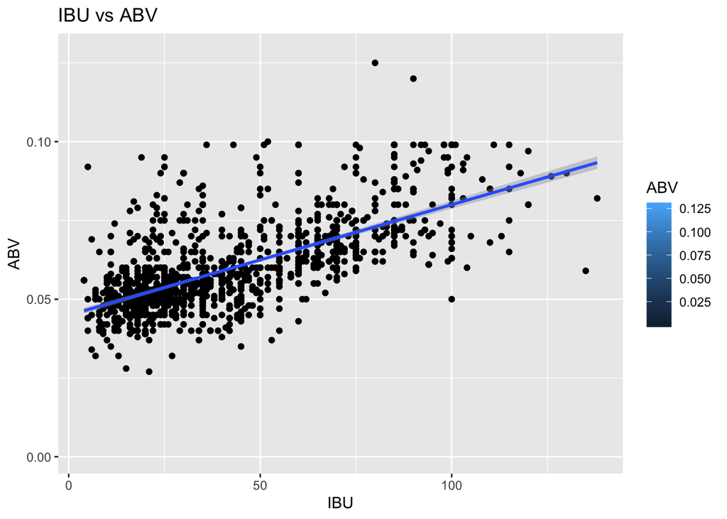

```r
#Scatter plot with linear model
Beer2 %>% ggplot(aes(x=IBU, y=ABV, fill = ABV)) + scale_colour_gradient()+ geom_point() + geom_smooth(method = lm) + ggtitle("IBU vs ABV") + xlab("IBU") + ylab("ABV")
```

```r
#Correlation of IBU and ABV
Beer3 <- Beer2 %>% filter(!is.na(Beer2$ABV))
Beer3 <- Beer3 %>% filter(!is.na(Beer3$IBU))
cor(x=Beer3$ABV, y=Beer3$IBU)
```

```
## [1] 0.6706215
```

## 8. Use KNN to investigate the difference between IPA and other Ales.

Given the scatterplot above, we’d like to know if ther is enough of a relationship between IBU and ABV to categorize a beer as either an IPA or an Ale knowing only these two numbers. We will use the K - Nearest Neighbors (KNN) test. This model will use K number of beers closest by distance (as you’d see on a scatterplot) to estimate what kind of beer it is.

To compare IPAs to other Ales, we broke up the beers into sets based on their beer type containing IPA or just Ale.

See Appendix for Full list of Beer Types

First we checked for the best K value to use to train the KNN. We split the dataset in half checking K values 1 to 80 for accuracy. For each K value we took the mean accuracy of 50 runs for comparison.

### KNN for classifying just IPAs and Non-IPA Ales; other styles are excluded

```r
#Identify IPAs, Non-IPA Ales, or other styles.
#All IPAs have "IPA" somehwere in the style name, so this can be used to identify IPA vs not IPA.

Beer3$Category[grepl("IPA", Beer3$Style)] <- "IPA"
Beer3$Category[is.na(Beer3$Category) & grepl("Ale", Beer3$Style)] <- "Non-IPA Ale"
Beer3$Category[is.na(Beer3$Category)] <- "Other"

Beer4 <- Beer3 %>% filter(Category == "IPA" | Category == "Non-IPA Ale")

#Identify the best k
#Set Split percentages for train and test sets
set.seed(10)
splitPerc = .5

#loop through values of k to find best model on 100 generated train/test combos
iterations = 50
numks = 80

masterAcc = matrix(nrow = iterations, ncol = numks)

for(j in 1:iterations)
{
accs = data.frame(accuracy = numeric(80), k = numeric(80))
trainIndices = sample(1:dim(Beer4)[1],round(splitPerc * dim(Beer4)[1]))
train = Beer4[trainIndices,]
test = Beer4[-trainIndices,]
for(i in 1:numks)
{
  classifications = knn(train[,c(4,5)],test[,c(4,5)],train$Category, prob = TRUE, k = i)
  table(classifications,test$Category)
  CM = confusionMatrix(table(classifications,test$Category))
  masterAcc[j,i] = CM$overall[1]
}

}
```

Based on the graph, you can see there is a high spike in accuracy at k=5 and it levels out after 30. Our model will use the closest 5 beers to estimate what category it should fall into.

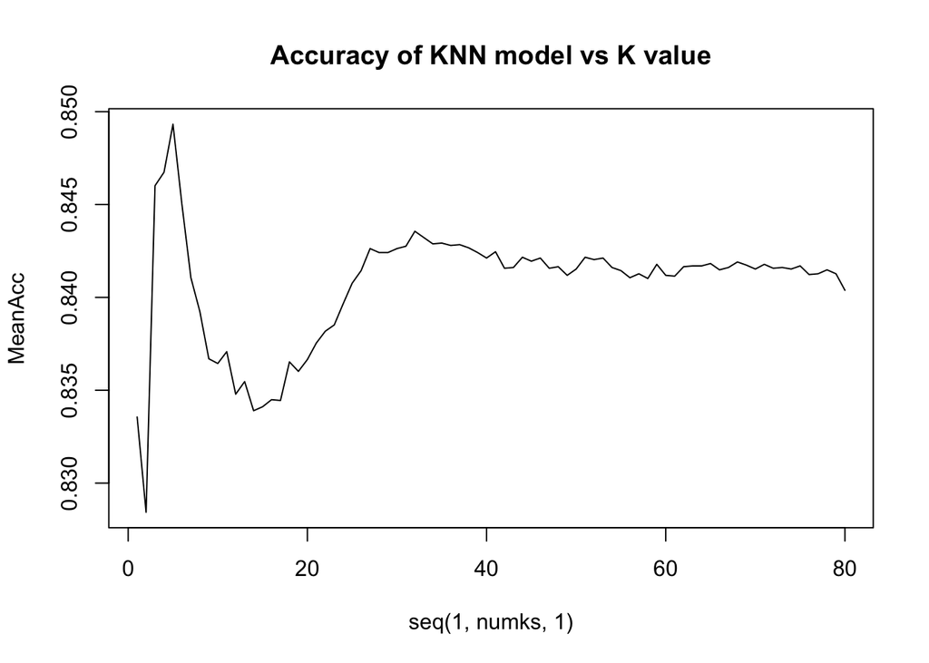

```r
MeanAcc = colMeans(masterAcc)
#plot k vs accuracy and identify k with highest accuracy
plot(seq(1,numks,1),MeanAcc, type = "l", main="Accuracy of KNN model vs K value")
```

```r
paste("Highest Accuraccy K Value is ", which.max(MeanAcc))
```

```
## [1] "Highest Accuraccy K Value is  5"
```

Using a KNN model with k=5, we could categorize beers into IPAs or Non-IPA Ales with about 87% accuracy using only IBU and ABV. This indicates that on average, there is a clear enough distinction between IPAs and other Ales in their combination of ABV and IBU to be able to reasonably identify an IPA from a different Ale based on these variables alone.

```r
#knn classification using the tuned value of k
set.seed(10)
trainIndices = sample(seq(1:length(Beer4$ABV)),round(.7*length(Beer4$ABV)))
trainBeer = Beer4[trainIndices,]
testBeer = Beer4[-trainIndices,]
classif <- knn(trainBeer[,4:5],testBeer[,4:5],trainBeer$Category, prob=TRUE, k=5)

confusionMatrix(table(classif,testBeer$Category))
```

```
## Confusion Matrix and Statistics
##
##
## classif       IPA Non-IPA Ale
##   IPA         104          17
##   Non-IPA Ale  21         141
##
##                Accuracy : 0.8657
##                  95% CI : (0.8204, 0.9032)
##     No Information Rate : 0.5583
##     P-Value [Acc > NIR] : <2e-16
##
##                   Kappa : 0.7268
##
##  Mcnemar's Test P-Value : 0.6265
##
##             Sensitivity : 0.8320
##             Specificity : 0.8924
##          Pos Pred Value : 0.8595
##          Neg Pred Value : 0.8704
##              Prevalence : 0.4417
##          Detection Rate : 0.3675
##    Detection Prevalence : 0.4276
##       Balanced Accuracy : 0.8622
##
##        'Positive' Class : IPA
##
```

### Plotting IPAs vs other Ales

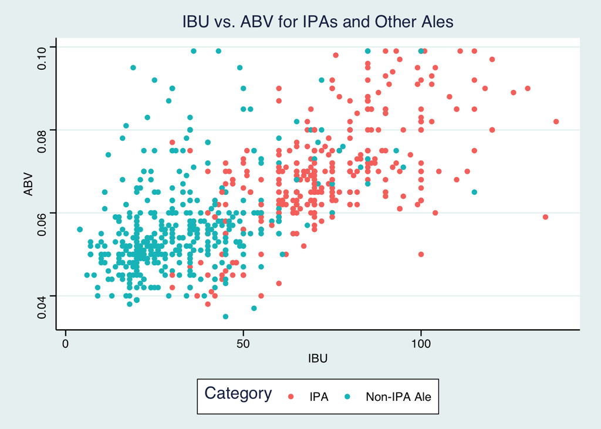

```r
Beer4 %>%
  ggplot(aes(x = IBU, y=ABV, color=Category)) + geom_point() + ggtitle("IBU vs. ABV for IPAs and Other Ales") +theme_stata()
```

# IPA vs APA - Does it matter?

With the younger generation quickly ditching ubiquitous light beers for bolder options from the craft beer market, it is time to evolve by attempting to add more inimitable options to our lineup of beer labels. The booming resurgence of craft beer brewing has fostered unbridled experimentation in pursuit of finding unique formulas that can distinguish a brewer amidst his many peers. The lines separating the classification of beer styles are becoming blurrier and the opportunity to discover a new flavor that entices the common imbiber is riper than ever.

The India Pale Ale is the most prevalent and still one of the fastest growing craft beer styles in America. Of the 2400 labels in this dataset, a third of them are classified as IPA or the similar APA. If Budweiser desires to cut into the craft brew market, this is an excellent place to start.

The marketing and development team for Budweiser has proposed that a new label be introduced to the Budweiser Lineup - The Bud IPA. The team wants to label the beer with IPA because of its popular namesake in the craft beer market, but is interested to know how much room for experimentation they have when it comes to IBU and ABV while still being able to keep the simple “Bud IPA” label.

There are traditional differences that have culminated in industry defined standards for what makes a beer an Indian Pale Ale vs an American Pale Ale. But as IPAs, their siblings, and cousins dominate the craft beer market, many are suggesting there isn’t really any difference between them anymore. Could this mean we have free reign to develop a unique brew that could fall anywhere in the range of ABV and IBU and label it as the all-encompassing “IPA”? Answering these questions could open the door to understanding just how ambitious the formulation for this new label could be.

## Is there any difference Between Pale Ales?

We can observe visually that there appears to be distinct differences in Bitterness and ABV for the 3 largest groups among IPAs and APAs.

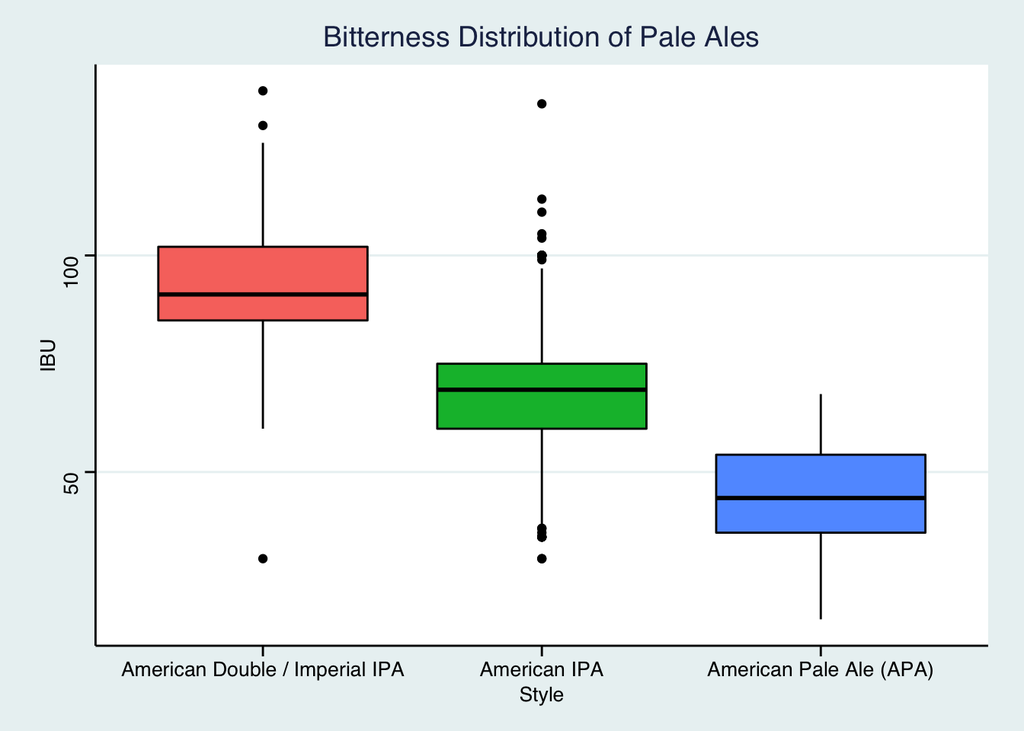

```r
# Boxplots of IBU for 3 different PAs
# Pare down data to just 3 groups of interest
IPAtest <- Beer3 %>% filter(Beer3$Style == "American IPA" | Beer3$Style ==  "American Double / Imperial IPA" | Beer3$Style == "American Pale Ale (APA)")

IPAtest %>%
  ggplot(aes(x = Style, y=IBU, fill=Style)) + geom_boxplot(color="black", show.legend = FALSE) + ggtitle("Bitterness Distribution of Pale Ales") +theme_stata()
```

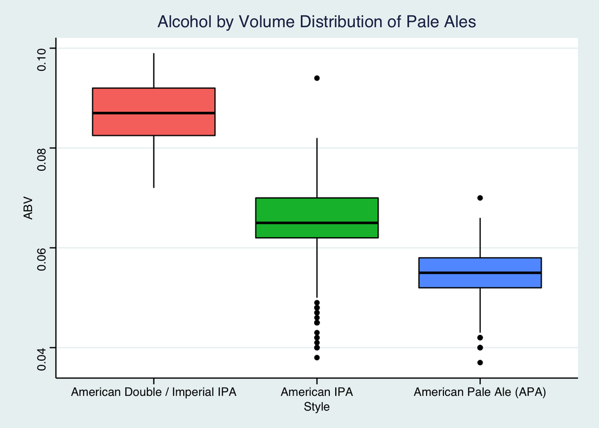

```r
# Boxplots of ABV for 3 different PAs
IPAtest %>%
  ggplot(aes(x = Style, y=ABV, fill=Style)) + geom_boxplot(color="black", show.legend = FALSE) + ggtitle("Alcohol by Volume Distribution of Pale Ales") +theme_stata()
```

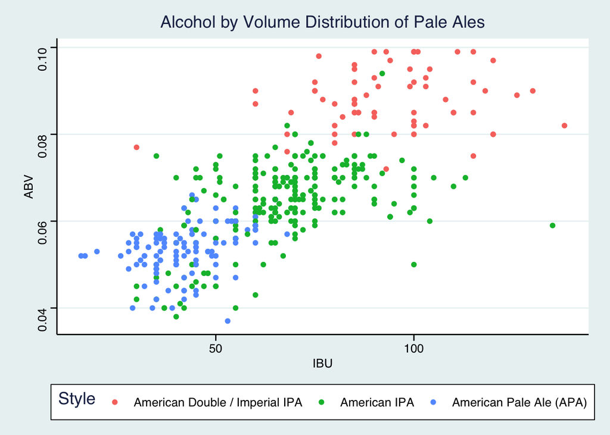

```r
#Relationship of ABV and IBU for the 3 groups
IPAtest %>%
  ggplot(aes(x = IBU, y=ABV, color=Style)) + geom_point() + ggtitle("Alcohol by Volume Distribution of Pale Ales") +theme_stata()
```

All of the plots show distinct separate groups for the 3 styles for both ABV and IBU. We can confirm whether or not there are any significant differences between the groups with an ANOVA.

See Appendix for assumption checks to confirm ANOVA can be performed IBU ANOVA Checks ABV ANOVA Checks

### ANOVA on IBU for the 3 groups

```r
#Run ANOVA on IBU for the 3 groups
IPAtest_IBU <- aov(IBU ~ Style, data=IPAtest)
summary(IPAtest_IBU)
```

```
##              Df Sum Sq Mean Sq F value Pr(>F)
## Style         2 123758   61879   270.6 <2e-16 ***
## Residuals   526 120301     229
## ---
## Signif. codes:  0 '***' 0.001 '**' 0.01 '*' 0.05 '.' 0.1 ' ' 1
```

### ANOVA on ABV for the 3 groups

```r
#Run ANOVA on ABV for the 3 groups
IPAtest_ABV <- aov(ABV ~ Style, data=IPAtest)
summary(IPAtest_ABV)
```

```
##              Df  Sum Sq Mean Sq F value Pr(>F)
## Style         2 0.05399 2.7e-02   460.7 <2e-16 ***
## Residuals   526 0.03082 5.9e-05
## ---
## Signif. codes:  0 '***' 0.001 '**' 0.01 '*' 0.05 '.' 0.1 ' ' 1
```

The F statistics and corresponding small p values confirm that there is significant evidence of at least one difference between the different groups for both IBU and ABV.

## Which groups are different?

To check which of three styles were different from each other, we ran hypothesis tests on the three combinations using Tukey-Kramer adjusted p-values.

### Tukey-Kramer IBU

```r
#Tukey-Kramer adjusted p values and confidence intervals for IBU differences between groups
TukeyHSD(IPAtest_IBU)
```

```
##   Tukey multiple comparisons of means
##     95% family-wise confidence level
##
## Fit: aov(formula = IBU ~ Style, data = IPAtest)
##
## $Style
##                                                             diff       lwr
## American IPA-American Double / Imperial IPA            -25.68545 -30.27274
## American Pale Ale (APA)-American Double / Imperial IPA -48.37882 -53.38917
## American Pale Ale (APA)-American IPA                   -22.69338 -26.22257
##                                                              upr p adj
## American IPA-American Double / Imperial IPA            -21.09816     0
## American Pale Ale (APA)-American Double / Imperial IPA -43.36848     0
## American Pale Ale (APA)-American IPA                   -19.16418     0
```

### Tukey-Kramer ABV

```r
#Tukey-Kramer adjusted p values and confidence intervals for ABV differences between groups
TukeyHSD(IPAtest_ABV)
```

```
##   Tukey multiple comparisons of means
##     95% family-wise confidence level
##
## Fit: aov(formula = ABV ~ Style, data = IPAtest)
##
## $Style
##                                                                diff         lwr
## American IPA-American Double / Imperial IPA            -0.022886024 -0.02520800
## American Pale Ale (APA)-American Double / Imperial IPA -0.032719477 -0.03525559
## American Pale Ale (APA)-American IPA                   -0.009833453 -0.01161984
##                                                                 upr p adj
## American IPA-American Double / Imperial IPA            -0.020564049     0
## American Pale Ale (APA)-American Double / Imperial IPA -0.030183364     0
## American Pale Ale (APA)-American IPA                   -0.008047062     0
```

# Conclusion

These tests provide overwhelming evidence (p values are essentially zero) of distinct differences in IBU and ABV between Standard American IPA’s, Double IPA’s, and APA’s. Based on this information, it would be prudent for Budweiser’s brewers to stick to the range for American IPA’s shown in this dataset of an IBU between 60-75 to be within the range of 50% of American IPA’s on market. IPAs tend to be on the higher alcohol content, but there are ABVs within the American IPA range and the overall middle 50% of ABVs of 6.2% to 6.7%. Staying within this range will keep it distinct from the American Pale Ales while not straying far from the drinkability people look for in Budweiser.

```r
print("American IPA beer Middle 50% distribution of IBU")
```

```
## [1] "American IPA beer Middle 50% distribution of IBU"
```

```r
IBUsummary = summary(filter(.data=IPAtest, Style == 'American IPA')$IBU)
paste("[",IBUsummary[2], ",", IBUsummary[5],"]")
```

```
## [1] "[ 60 , 75 ]"
```

```r
print("American IPA beer Middle 50% distribution of ABV ")
```

```
## [1] "American IPA beer Middle 50% distribution of ABV "
```

```r
ABVsummary = summary(filter(.data=IPAtest, Style == 'American IPA')$ABV)
paste("[",ABVsummary[2], ",", ABVsummary[5],"]")
```

```
## [1] "[ 0.062 , 0.07 ]"
```

```r
print("Overall American Beer Middle 50% distribution ABV")
```

```
## [1] "Overall American Beer Middle 50% distribution ABV"
```

```r
overallSummary = summary(Beer2$ABV)
paste("[",overallSummary[2],",",overallSummary[5],"]")
```

```
## [1] "[ 0.05 , 0.067 ]"
```

In our review we found many beers were missing information on their IBU. This scale is not as widespread in America as it is in other countries. When Adolphus Busch started Budweiser, he was looking to make Americans love beer. Now Budweiser could bring this distinct flavor to a broader audience by inviting them to fall in love with the American IPA.

# Appendix

## Raw Datasets

```r
breweries
```

```
##     Brew_ID                                Name                City State
## 1         1                  NorthGate Brewing          Minneapolis    MN
## 2         2           Against the Grain Brewery          Louisville    KY
## 3         3            Jack's Abby Craft Lagers          Framingham    MA
## 4         4           Mike Hess Brewing Company           San Diego    CA
## 5         5             Fort Point Beer Company       San Francisco    CA
## 6         6               COAST Brewing Company          Charleston    SC
## 7         7        Great Divide Brewing Company              Denver    CO
## 8         8                    Tapistry Brewing            Bridgman    MI
## 9         9                    Big Lake Brewing             Holland    MI
## 10       10          The Mitten Brewing Company        Grand Rapids    MI
## 11       11                      Brewery Vivant        Grand Rapids    MI
## 12       12                    Petoskey Brewing            Petoskey    MI
## 13       13                  Blackrocks Brewery           Marquette    MI
## 14       14              Perrin Brewing Company       Comstock Park    MI
```

[output cut: 544 more lines]

```r
beers
```

```
##                                                      Name Beer_ID   ABV IBU
## 1                                                Pub Beer    1436 0.050  NA
## 2                                             Devil's Cup    2265 0.066  NA
## 3                                     Rise of the Phoenix    2264 0.071  NA
## 4                                                Sinister    2263 0.090  NA
## 5                                           Sex and Candy    2262 0.075  NA
## 6                                            Black Exodus    2261 0.077  NA
## 7                                     Lake Street Express    2260 0.045  NA
## 8                                                 Foreman    2259 0.065  NA
## 9                                                    Jade    2258 0.055  NA
## 10                                           Cone Crusher    2131 0.086  NA
## 11                                      Sophomoric Saison    2099 0.072  NA
## 12                                  Regional Ring Of Fire    2098 0.073  NA
## 13                                             Garce Selé    2097 0.069  NA
## 14                                        Troll Destroyer    1980 0.085  NA
```

[output cut: 4807 more lines]

## Median ABV

In order of Highest to Lowest ABVs

```r
med_ABV <-Meds[order(-Meds$Median_ABV),]
med_ABV
```

```
## # A tibble: 51 x 4
##    State Median_ABV Median_IBU fips
##    <fct>      <dbl>      <dbl> <chr>
##  1 " DC"     0.0625       47.5 11
##  2 " KY"     0.0625       31.5 21
##  3 " MI"     0.062        35   26
##  4 " NM"     0.062        51   35
##  5 " WV"     0.062        57.5 54
##  6 " CO"     0.0605       40   08
##  7 " AL"     0.06         43   01
##  8 " CT"     0.06         29   09
##  9 " NV"     0.06         41   32
## 10 " OK"     0.06         35   40
## # … with 41 more rows
```

## Median IBU

In order of Highest to Lowest IBUs

```r
med_IBU <- Meds[order(-Meds$Median_IBU),]
med_IBU
```

```
## # A tibble: 51 x 4
##    State Median_ABV Median_IBU fips
##    <fct>      <dbl>      <dbl> <chr>
##  1 " ME"     0.051        61   23
##  2 " WV"     0.062        57.5 54
##  3 " FL"     0.057        55   12
##  4 " GA"     0.055        55   13
##  5 " DE"     0.055        52   10
##  6 " NM"     0.062        51   35
##  7 " NH"     0.055        48.5 33
##  8 " DC"     0.0625       47.5 11
##  9 " NY"     0.055        47   36
## 10 " AK"     0.056        46   02
## # … with 41 more rows
```

## Beer Types

```r
beertypes =unique(factor(Beer2$Style))
beertypes[order(beertypes)]
```

```
##   [1]                                     Abbey Single Ale
##   [3] Altbier                             American Adjunct Lager
##   [5] American Amber / Red Ale            American Amber / Red Lager
##   [7] American Barleywine                 American Black Ale
##   [9] American Blonde Ale                 American Brown Ale
##  [11] American Dark Wheat Ale             American Double / Imperial IPA
##  [13] American Double / Imperial Pilsner  American Double / Imperial Stout
##  [15] American India Pale Lager           American IPA
##  [17] American Malt Liquor                American Pale Ale (APA)
##  [19] American Pale Lager                 American Pale Wheat Ale
##  [21] American Pilsner                    American Porter
##  [23] American Stout                      American Strong Ale
##  [25] American White IPA                  American Wild Ale
##  [27] Baltic Porter                       Belgian Dark Ale
##  [29] Belgian IPA                         Belgian Pale Ale
```

[output cut: 36 more lines]

## ANOVA IBU CHECKS

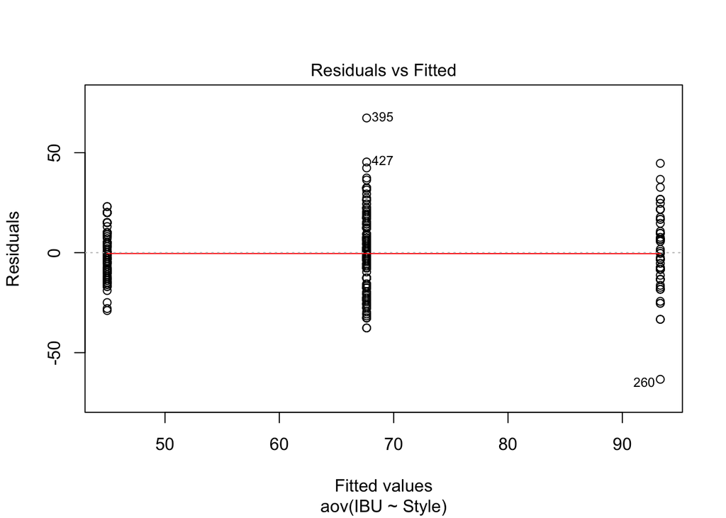

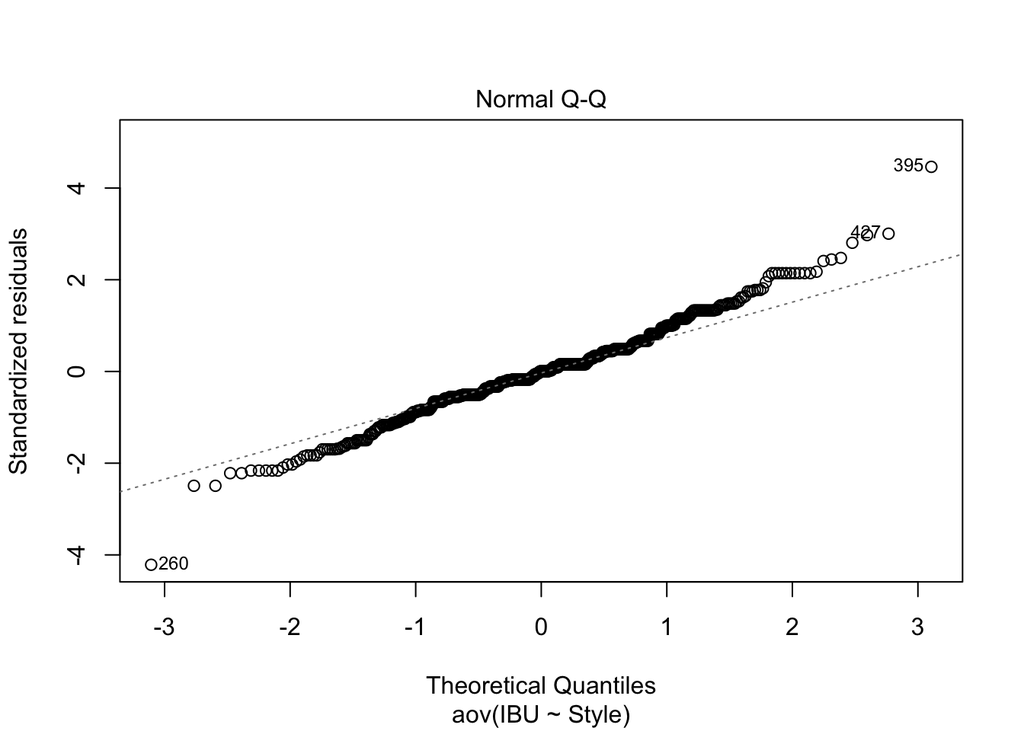

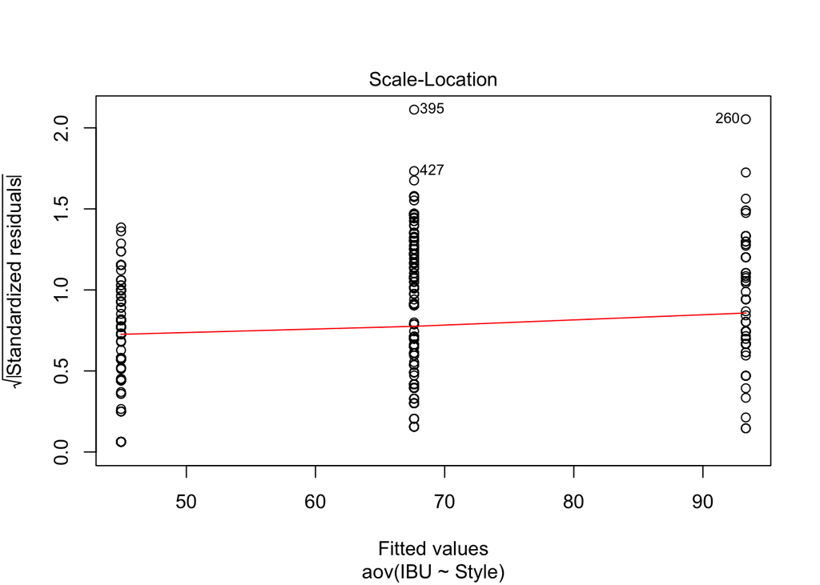

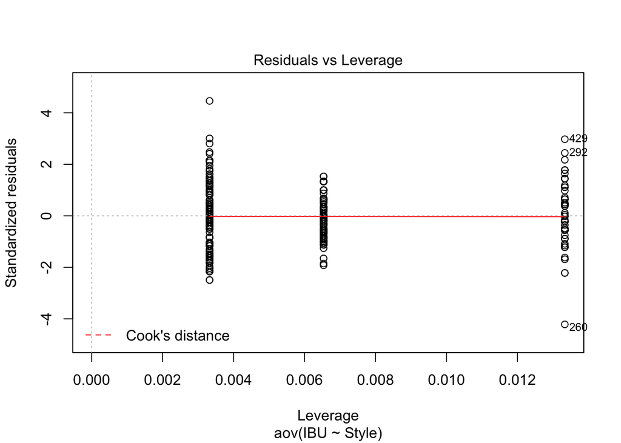

```r
plot(IPAtest_IBU) #for checking assumptions for ANOVA
```

## ANOVA ABV CHECKS

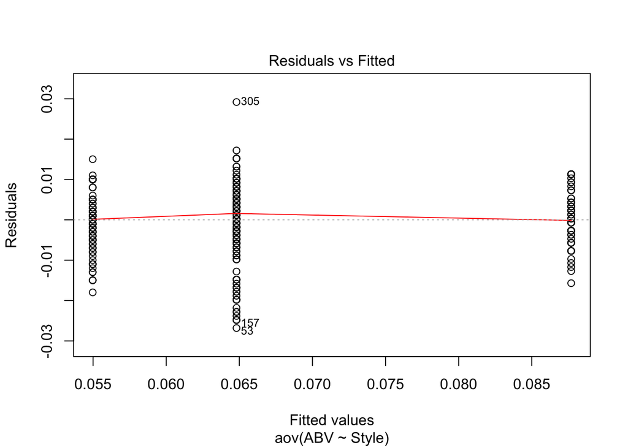

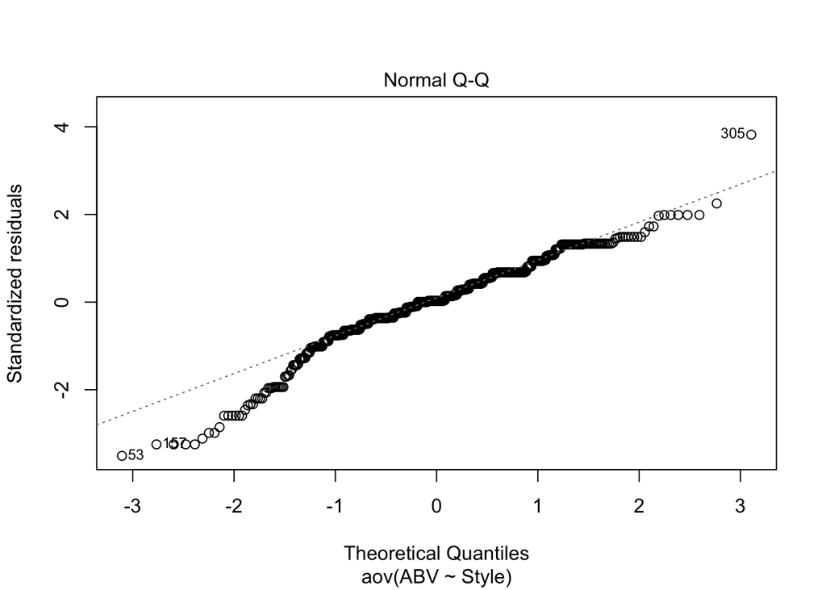

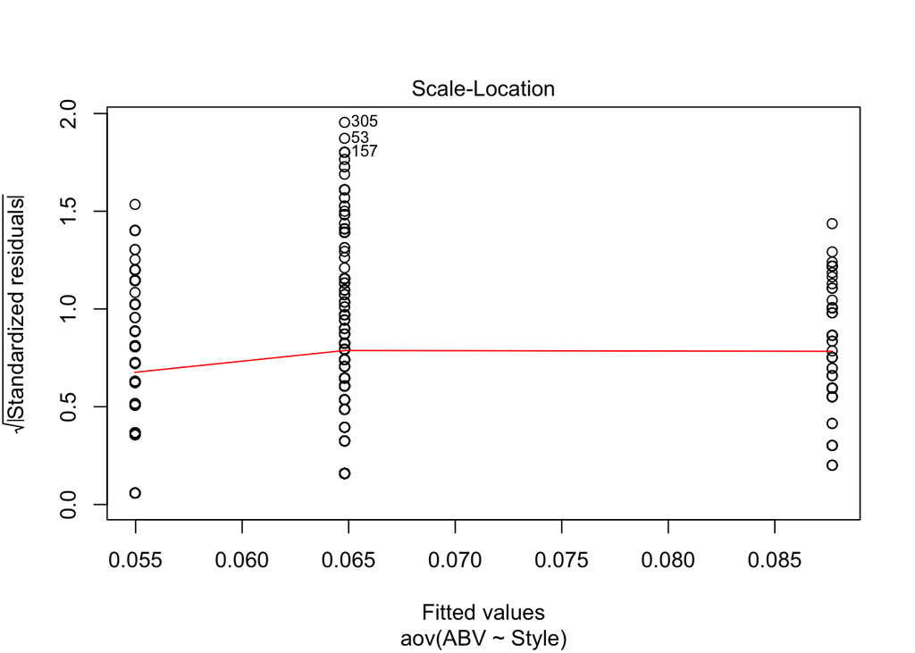

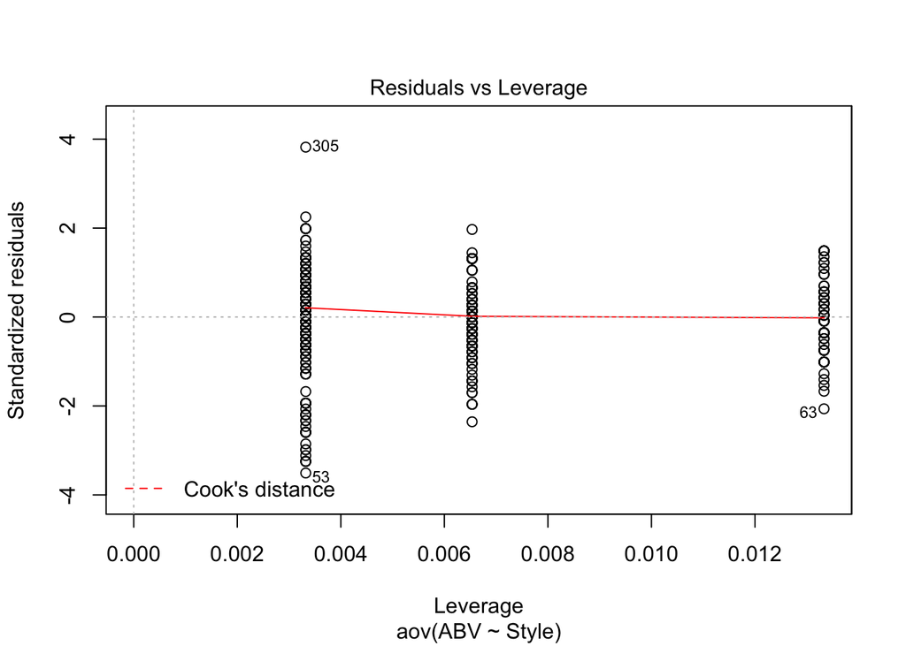

```r
plot(IPAtest_ABV) #for checking assumptions for ANOVA
```